# Human Freedom Index

Committee

July 23, 2019

# The Human Freedom Index

“The Human Freedom Index presents the state of human freedom in the world based on a broad measure that encompasses personal, civil, and economic freedom.”

The report is co-published by the Cato Institute, the Fraser Institute, and the Liberales Institut at the Friedrich Naumann Foundation for Freedom. For more details on the Human Freedom Index Project, see https://www.cato.org/human-freedom-index-new.

# Project Topic

The Human Index freedom is constructed of 162 counties that combines economic freedom measurements with personal freedom measurements. The index aims to understand the degree of freedom people are able to enjoy classic civil liberties from the countries that were surveyed. We will investigate the correlations between personal and economic freedom to see if one can be a predictor for the other, and specifically examine the subcategories of the two indeces.

# Personal Freedom

- Rule of Law (rol)
- Security and Safety (safety)
- Movement (movement)
- Religion (religion)
- Association, Assembly, and Civil Society (assembly)
- Expression and Information (expression)
- Identity and Relationships (relationships)

# Economic Freedom

- Size of Government (govsize)
- Legal System and Property Rights (legalsystems)
- Access to Sound Money (money)
- Freedom to Trade Internationally (trade)
- Regulation of Credit, Labor, and Business (regulation)

# Summary of Personal Freedom Index

```
##    Min. 1st Qu.  Median    Mean 3rd Qu.    Max.
##   2.167   6.025   6.932   6.985   8.142   9.399
```

# Summary of Economic Freedom Index

The economic freedom sub-index is comprised of 42 numerical variables divided into five categories. The indicators are rated on a sale of 1 to 10, with 10 representing the most freedom.

```
##    Min. 1st Qu.  Median    Mean 3rd Qu.    Max.
##   2.880   6.260   6.905   6.795   7.468   8.970
```

# Economic Freedom vs. Personal Freedom

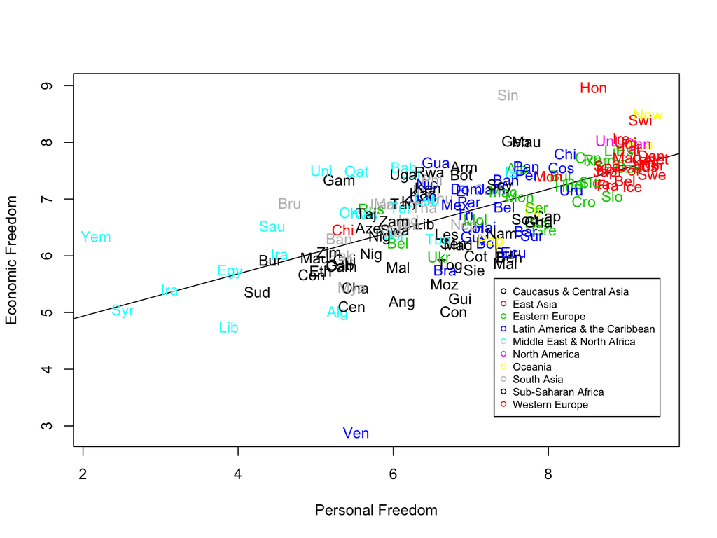

There is a clear positive correlation between personal and economic freedom, with a correlation of 0.6271777.

# Economic Freedom vs. Rule of Law

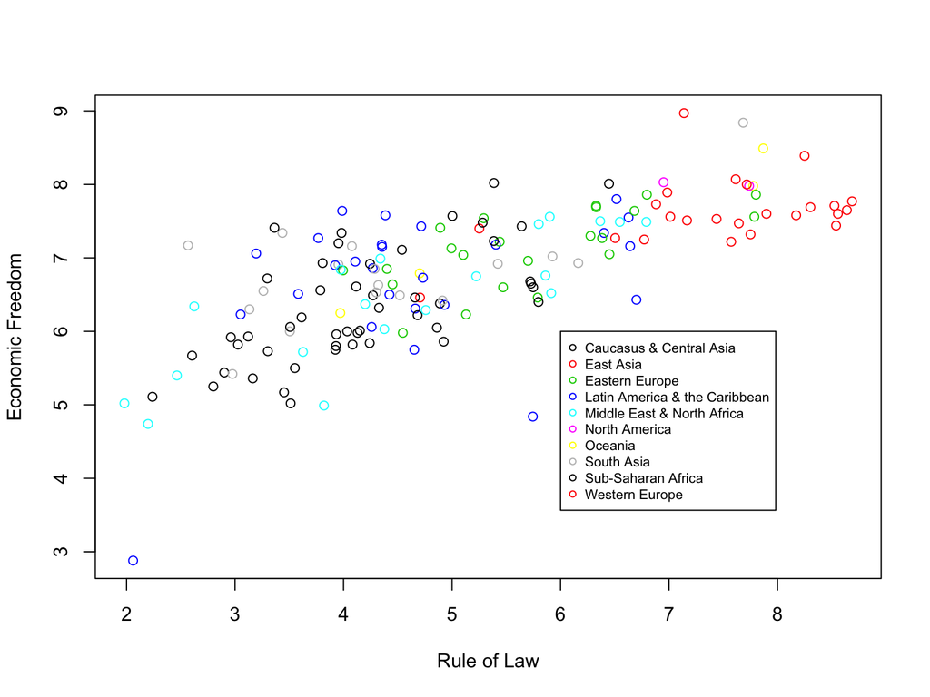

# Economic Freedom vs. Security and Safety

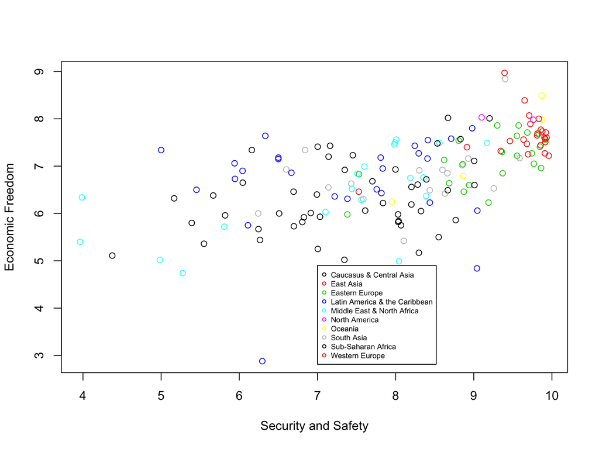

# Economic Freedom vs. Movement

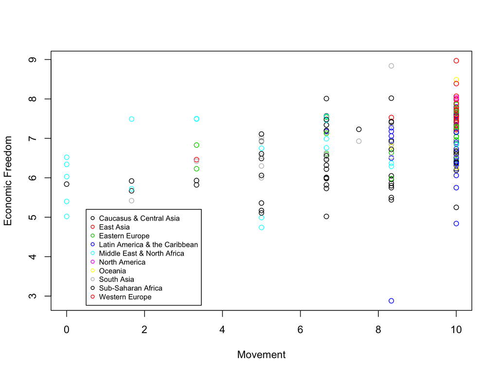

# Economic Freedom vs. Religion

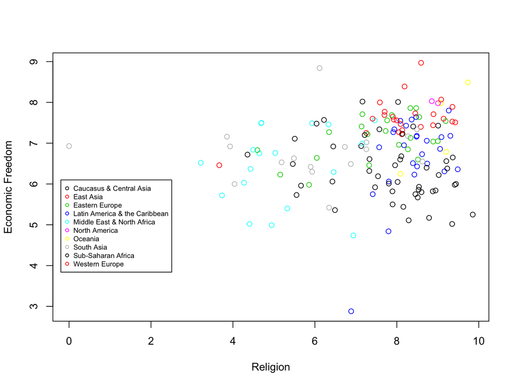

# Economic Freedom vs. Association, Assembly, and Civil Society

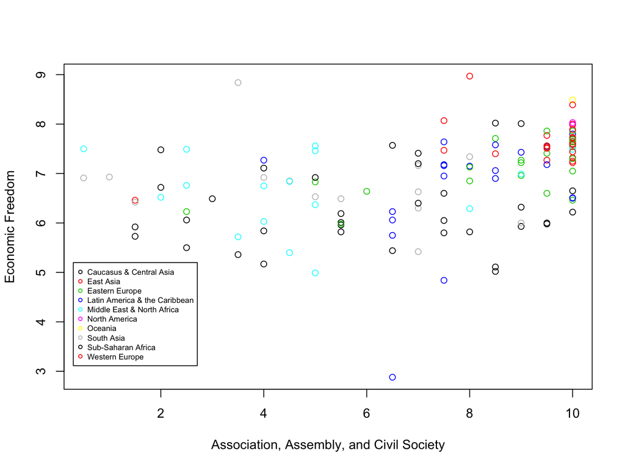

# Economic Freedom vs. Expression and Information

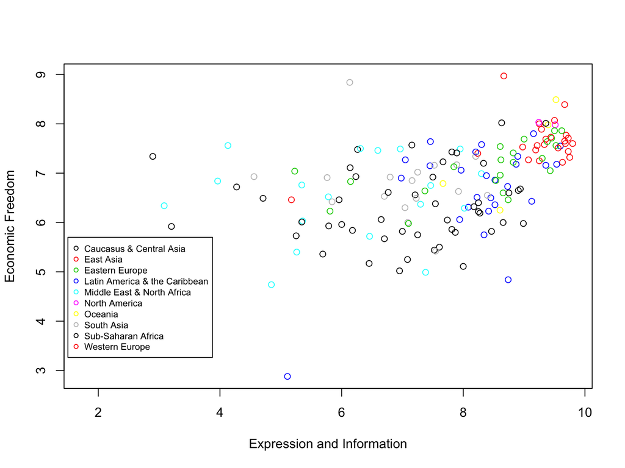